# Birth-death models

How lineages multiply and vanish

## Last time

We used a **tree** to learn about how **sequences** evolve

But where does the tree come from?

Today: What process **grows** a tree, and what can a tree of living species tell us about that process?

# Lineages that split

## Birth-death (BD) models

Every branch of a tree of species is a *lineage*

- Each lineage splits in two (*speciation*, or “birth”) at rate $\lambda$
- Each lineage dies out (*extinction*, or “death”) at rate $\mu$
- Rates are per lineage, per unit of time (*e.g.*, per million years)
- When $\mu = 0$, it’s the *pure-birth* (or *Yule*) model<sup>1</sup>

The same models describe anything that multiplies and dies

- Cells in a tumor, individuals in a population, **infections in an epidemic**
[^1]: Yule (1925)

## One lineage is like one site

In the substitution models exercise, a site waited an **exponential** time before its next change

A lineage waits an exponential time, with rate $\lambda$, before it splits

With $n$ lineages, each with speciation rate $\lambda$ and extinction rate $\mu$:

$$\text{total rate} = n\lambda + n\mu = n(\lambda + \mu)$$

The more lineages there are, the faster new ones appear!

## The Gillespie algorithm<sup>1</sup>

Simulate one event at a time:

1. Calculate the **total rate**: $n(\lambda + \mu)$
2. Draw an exponential **waiting time** using the total rate, and move the clock forward
3. Choose **which event** happened:
   - A split, with probability $\frac{\lambda}{\lambda + \mu}$ ($n$ goes up by 1)
   - An extinction otherwise ($n$ goes down by 1)
4. Repeat until the clock passes the present, or $n = 0$
[^2]: Gillespie (1977)

## Growing a tree, event by event

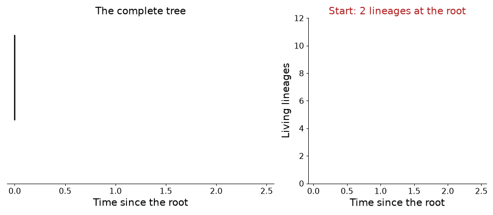

## Pure-birth simulations and expectations

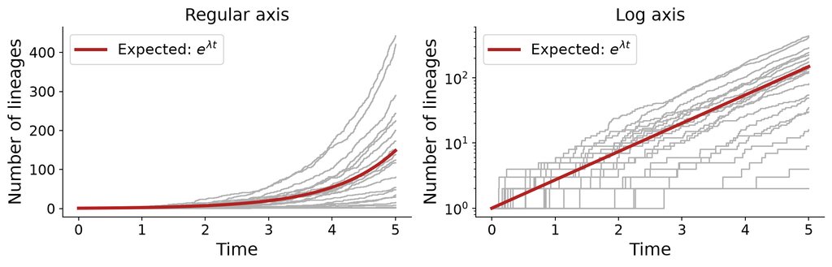

- The number of lineages grows **exponentially** with rate $\lambda$
  - When $\mu > 0$, the exponential growth rate is $r = \lambda - \mu$
- **Questions**: Why are the curves straight on a log axis? Why do they differ the most near the start?

# Adding extinction

## How often does a clade die out?

| Death rate, $\mu$ ($\lambda = 1$) | Extinct by time 5 (simulated) | Eventually extinct |
| --- | --- | --- |
| 0.00 | 0.00 | 0.00 |
| 0.25 | 0.23 | 0.25 |
| 0.50 | 0.49 | 0.50 |
| 0.75 | 0.70 | 0.75 |
| 1.00 | 0.82 | 1.00 |

A clade that starts with one lineage eventually dies out with probability $\mu / \lambda$ (when $\mu < \lambda$)<sup>1</sup>

Even when splits are **twice** as common as extinctions, about **half** of all clades die out

[^3]: Kendall (1948)

## Every clade we study is a survivor

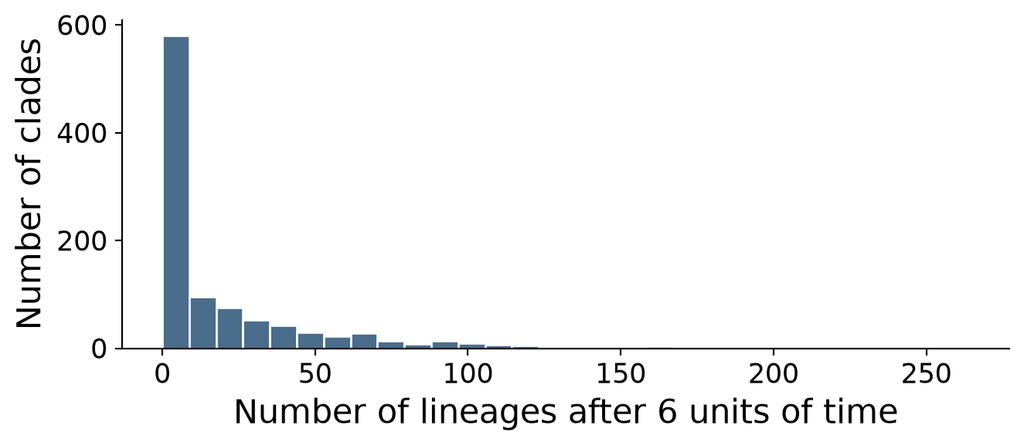

$\lambda = 1$, $\mu = 0.5$: 48% of clades are extinct; survivors average 37 lineages

- That’s about **twice** the expectation of the BD process ($e^{rt} \approx 20$)
- Question: How might studying only the “winners” bias what we learn?
- This is why phylogenetic BD methods condition on survival

# What do we observe?

## Complete vs. reconstructed trees

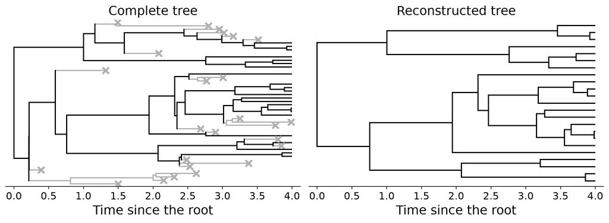

The *reconstructed tree*<sup>1</sup> is what we estimate from data: Sans unsampled extant species and most extinct lineages

[^4]: Nee et al. (1994)

## Lineages through time

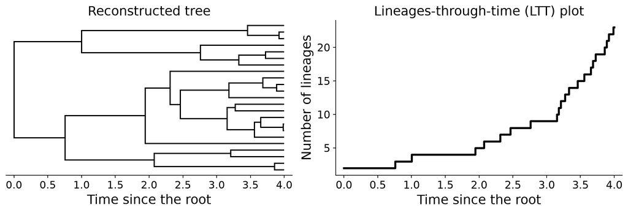

2 lineages at the root, and every split adds one, so all we need are the *branching times*: the times of the internal nodes

## The pull of the present

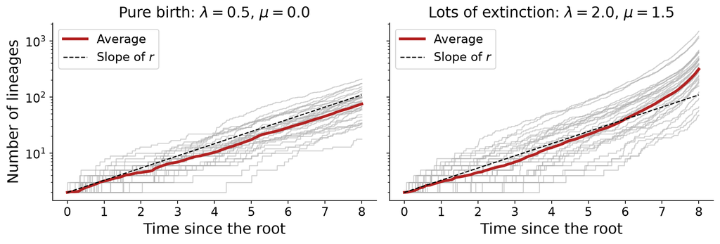

Both BD models have the same net diversification rate, $r = \lambda - \mu = 0.5$

Question: Why does extinction make the LTT plot bend **up** near the present?

# Bent-toed geckos

## *Cyrtodactylus*

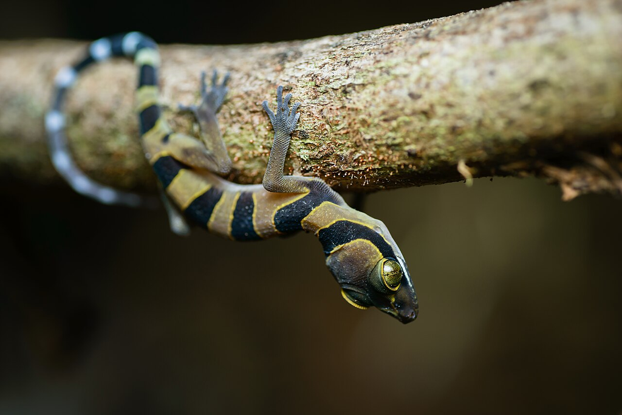

[*Cyrtodactylus lekaguli*](https://commons.wikimedia.org/wiki/File:Cyrtodactylus_lekaguli.jpg)

[*Cyrtodactylus lekaguli*](https://commons.wikimedia.org/wiki/File:Cyrtodactylus_lekaguli.jpg) Rushenb (2016) Wikimedia Commons

## *Cyrtodactylus*

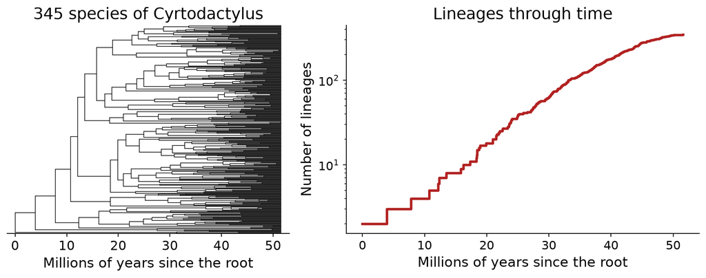

A time-calibrated tree<sup>1</sup> of 345 of the 406 described species<sup>2</sup>; the root is about 52 million years old

[^5]: Grismer et al. (2022)
[^6]: Uetz et al. (2026)

## Estimating the birth rate

Under **pure birth**, the maximum likelihood estimate of $\lambda$ is:

$$\hat{\lambda} = \frac{n - 2}{L}$$

- $n - 2$: the number of splits after the root
- $L$: the sum of all branch lengths, the total time lineages had to split
- So $\hat{\lambda}$ is splits per lineage per unit of time

We can simulate trees under the model, and ask: **Does the gecko tree look like them?**

## Unsampled species

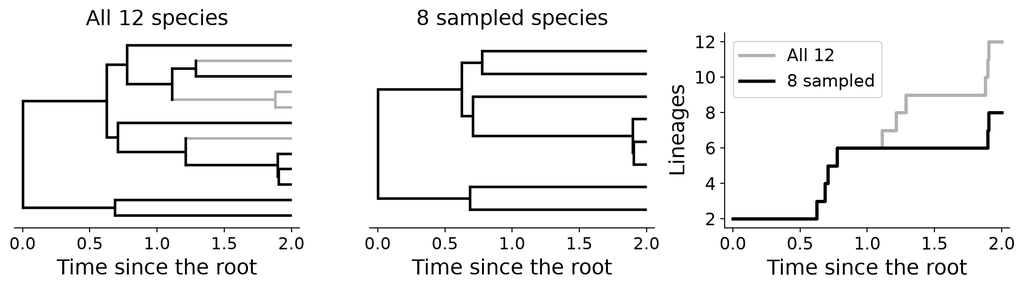

Every unsampled species removes a split, mostly **recent** ones, so the LTT plot flattens near the present

The gecko tree is missing at least 61 described species. Question: How many species would a pure-birth model need to explain the gecko tree?

## Summary

- In a **birth-death model**, each lineage splits at rate $\lambda$ and dies out at rate $\mu$
- The **Gillespie algorithm** simulates it one event at a time: total rate → waiting time → which event
- Lineages grow **exponentially**, but many clades go **extinct**, so living clades are a biased sample of “winners”
- We usually see only the **reconstructed tree**; extinction leaves a subtle signature in it, the **pull of the present**
- An **LTT plot** summarizes a tree, so we can compare real trees to the model
- **Unsampled species** remove recent splits, which flattens an LTT plot near the present

## In the exercise

1. `simulate_pure_birth` and `simulate_birth_death`: The Gillespie algorithm
2. How often do clades go extinct?
3. `plot_final_counts`: Your first plot!
4. `get_branching_times`: LTT plots and the pull of the present
5. `estimate_birth_rate` and `simulate_sampled_tree`: Lineages of bent-toed geckos through time

**Watch for**

Under a pure-birth model, how many gecko species are still undescribed?

## Exercise

1. Log into [molab](https://molab.marimo.io/)
2. [Open the exercise in molab](https://molab.marimo.io/github/phyletica/intro-to-comp-bio/blob/main/notebooks/nb-09-birth-death/birth_death.py)
3. Click “Fork” button

# References

Gillespie, Daniel T. 1977. “Exact Stochastic Simulation of Coupled Chemical Reactions.” *The Journal of Physical Chemistry* 81 (25): 2340–61. https://doi.org/10.1021/j100540a008.

Grismer, L. Lee, Nikolay A. Poyarkov, Evan S. H. Quah, Jesse L. Grismer, and Perry L. Wood, Jr. 2022. “The Biogeography of Bent-Toed Geckos, *Cyrtodactylus* (Squamata: Gekkonidae).” *PeerJ* 10: e13153. https://doi.org/10.7717/peerj.13153.

Kendall, David G. 1948. “On the Generalized ‘Birth-and-Death’ Process.” *Annals of Mathematical Statistics* 19 (1): 1–15. https://doi.org/10.1214/aoms/1177730285.

Nee, Sean, Robert M. May, and Paul H. Harvey. 1994. “The Reconstructed Evolutionary Process.” *Philosphical Transactions of the Royal Society B* 344: 305–11. https://doi.org/10.1098/rstb.1994.0068.

Uetz, P., P. Freed, R. Aguilar, F. Reyes, J. Kudera, and J. Hošek. 2026. “The Reptile Database.” https://www.reptile-database.org/.

Yule, George Udny. 1925. “A Mathematical Theory of Evolution, Based on the Conclusions of Dr. J. C. Willis, F.R.S.” *Philosphical Transactions of the Royal Society B* 213: 21–87. https://doi.org/10.1098/rstb.1925.0002.

## Acknowledgements

I drafted and iterated on these slides in collaboration with Anthropic’s Claude (Opus 5.5 model).